# Data_mining_final_prj_Analysis

#### Comparison plots

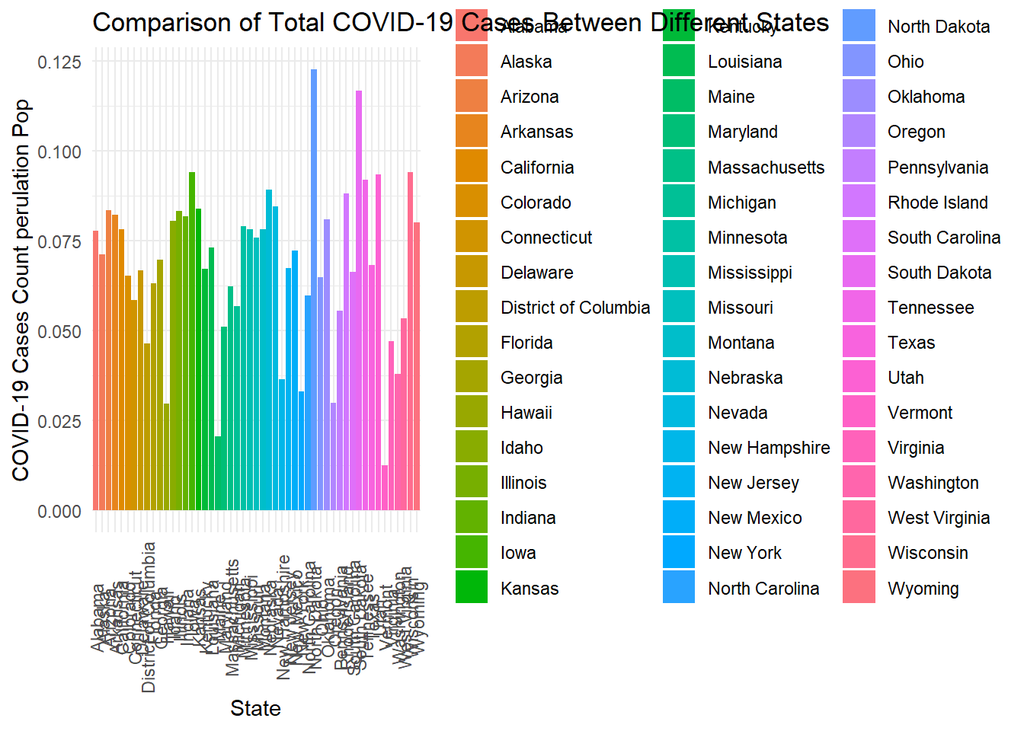

```r
#Comparison plots:

#Compare COVID-19 trends between different states or regions using bar charts
# Aggregate COVID-19 cases by state (e.g., total cases for each state)
agg_data <- aggregate(covid_case_count_per_pop ~ State,
                      data = master_copy_2020, FUN = sum)

# Create a bar chart comparing total COVID-19 cases between different states
ggplot(agg_data, aes(x = State, y = covid_case_count_per_pop, fill = State)) +
  geom_bar(stat = "identity") +
  labs(title = "Comparison of Total COVID-19 Cases Between Different States",
       x = "State",
       y = "COVID-19 Cases Count perulation Pop") +
  theme_minimal() +
  theme(axis.text.x = element_text(angle = 90, vjust = 0.5))
```

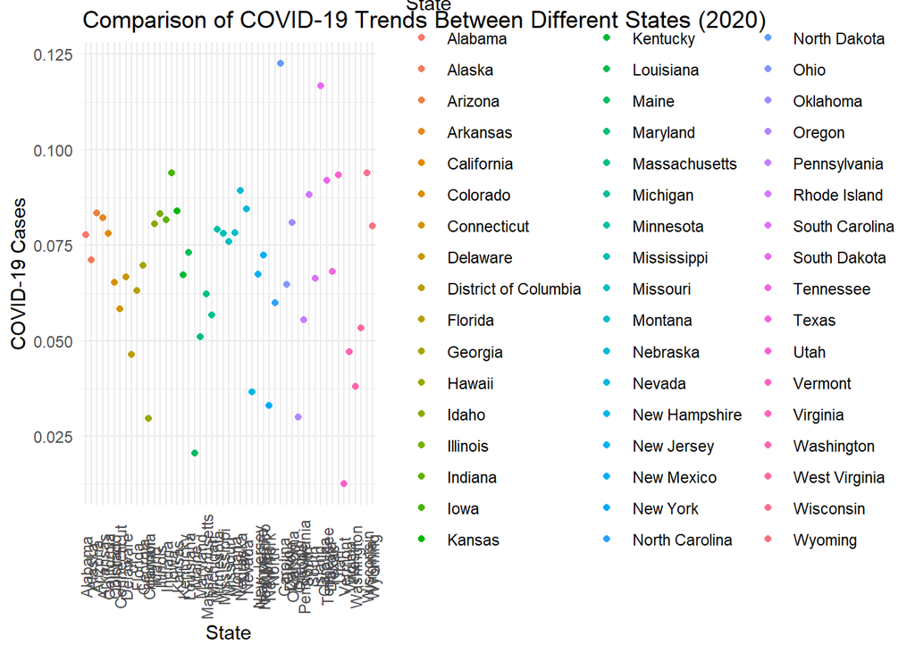

```r
#Compare COVID-19 trends between different states or regions using line plot
# Create a line plot comparing COVID-19 trends between different states for the year 2020
ggplot(master_copy_2020, aes(x = factor(State), y = covid_case_count_per_pop, color = State, group = State)) +
  geom_point() +
  labs(title = "Comparison of COVID-19 Trends Between Different States (2020)",
       x = "State",
       y = "COVID-19 Cases") +
  theme_minimal() +
  theme(axis.text.x = element_text(angle = 90, vjust = 0.5)) +
  scale_x_discrete(labels = function(x) str_wrap(x, width = 10))
```

### Model Creation/Building:(Ridge & Linear Regression, and K-Nearest Neighbor)

```r
# Explore the data
glimpse(master_copy_2020)
```

```
## Rows: 51
## Columns: 36
## $ State                                                  <chr> "Alabama", "Ala…
## $ total_new_cases_2020                                   <dbl> 384185, 47828, …
## $ average_pop                                            <dbl> 4861189.3, 6744…
## $ White_including_Hispanic_2020                          <dbl> 3465758, 473697…
## $ Black_including_Hispanic_2020                          <dbl> 1349908, 26720,…
## $ Other_including_Hispanic_2020                          <dbl> 91337, 57077, 2…
## $ American_Indian_Alaskan_Native_including_Hispanic_2020 <dbl> 35466, 114935, …
## $ White_including_Hispanic_percent                       <dbl> 70.20693, 70.69…
## $ Black_including_Hispanic_Percent                       <dbl> 27.2759937, 4.0…
## $ Other_including_Hispanic_Percent                       <dbl> 1.806705, 8.384…
## $ American_Indian_including_Hispanic_Percent             <dbl> 0.7103725, 16.9…
## $ avg_total_population_2020                              <dbl> 4942469, 672429…
## $ Percentage_population_0_4                              <dbl> 5.9, 6.8, 5.7, …
```

[output cut: 23 more lines]

#### Linear Regression

##### Model 0

- **Analyze the model’s performance and summarize your findings.**

```r
# Identify missing values
missing_values <- sum(is.na(master_copy_2020))

# Impute missing values (replace NA with mean)
master_copy_2020 <- na.omit(master_copy_2020)

# Check for missing values after imputation
missing_values_after_imputation <- sum(is.na(master_copy_2020))
missing_values_after_imputation
```

```
## [1] 0
```

```r
# Linear Regression with 1predictors
lm_model <- train(covid_case_count_per_pop ~ Median_Household_Income_2020,
                   data = master_copy_2020,
                   method = "lm")
summary(lm_model)
```

```
##
## Call:
## lm(formula = .outcome ~ ., data = dat)
##
## Residuals:
##       Min        1Q    Median        3Q       Max
## -0.056029 -0.009162  0.002288  0.013186  0.052168
##
## Coefficients:
##                                Estimate Std. Error t value Pr(>|t|)
## (Intercept)                   1.072e-01  1.914e-02   5.601 1.08e-06 ***
## Median_Household_Income_2020 -5.715e-07  2.839e-07  -2.013   0.0499 *
## ---
## Signif. codes:  0 '***' 0.001 '**' 0.01 '*' 0.05 '.' 0.1 ' ' 1
##
## Residual standard error: 0.0217 on 47 degrees of freedom
## Multiple R-squared:  0.07937,    Adjusted R-squared:  0.05978
## F-statistic: 4.052 on 1 and 47 DF,  p-value: 0.04987
```

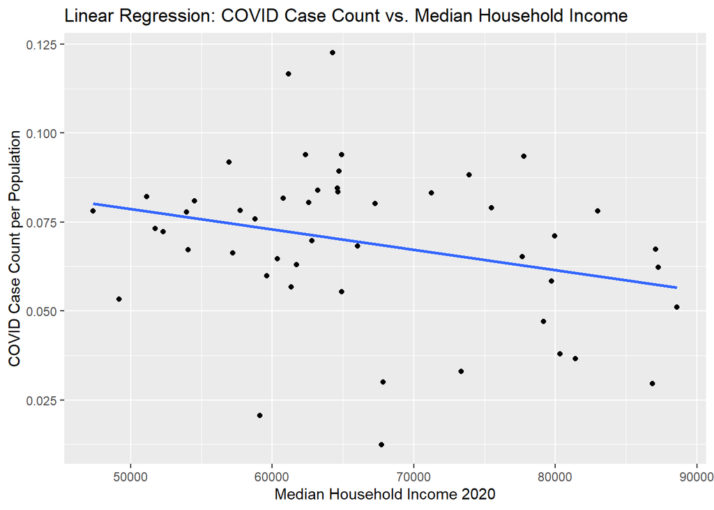

```r
# Predict COVID-19 case counts using the linear regression model
predictions <- predict(lm_model)

# Create scatter plot
ggplot(master_copy_2020, aes(x = Median_Household_Income_2020, y = covid_case_count_per_pop)) +
  geom_point() +  # Add points
  geom_smooth(method = "lm", se = FALSE) +  # Add linear regression line
  labs(x = "Median Household Income 2020", y = "COVID Case Count per Population") +  # Add axis labels
  ggtitle("Linear Regression: COVID Case Count vs. Median Household Income")  # Add plot title
```

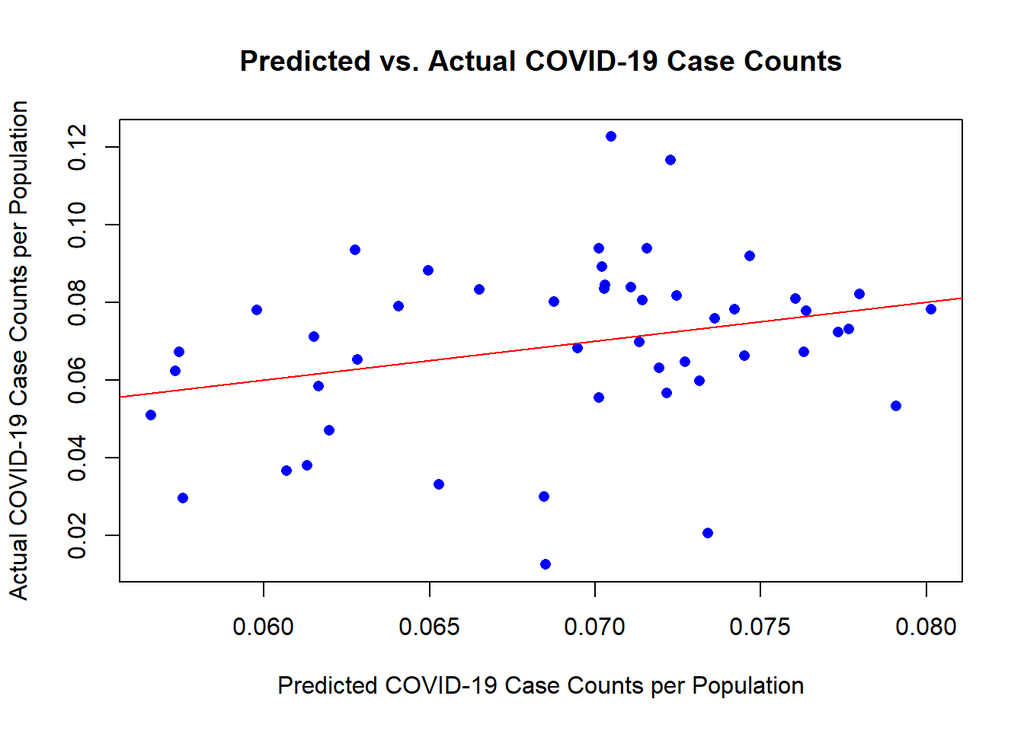

```r
# Create a scatter plot of actual vs. predicted COVID-19 case counts
plot(y= master_copy_2020$covid_case_count_per_pop, x = predictions,
     main = "Predicted vs. Actual COVID-19 Case Counts",
     ylab = "Actual COVID-19 Case Counts per Population",
     xlab = "Predicted COVID-19 Case Counts per Population",
     col = "blue",
     pch = 16)

# Add a diagonal line to represent perfect predictions
abline(0, 1, col = "red")
```

##### Model 1

- **`Here is the model summary`**: - **Coefficients**: Each coefficient represents the estimated change in the response variable (COVID-19 case count per population) for a one-unit change in the predictor variable, holding other variables constant.
  - **Intercept**: The intercept represents the estimated COVID-19 case count per population when all predictor variables are zero.
  - **Poverty_Percentage_2020**: The coefficient for this predictor is -8.873e-02, but it is not statistically significant (p = 0.5024), suggesting that there is no significant linear relationship between poverty percentage and COVID-19 case count per population.
  - **avg_annual_death_from_COPD_2020**: The coefficient is -1.146e-05, and it is also not statistically significant (p = 0.5699), indicating no significant linear relationship between average annual deaths from COPD and COVID-19 case count per population.
  - **Median_Household_Income_2020**: The coefficient is -8.500e-07, but it is not statistically significant at the conventional level (p = 0.1016), suggesting a weak or uncertain linear relationship between median household income and COVID-19 case count per population.
  - **avg_total_population_2020**: The coefficient is -3.528e-11, and it is not statistically significant (p = 0.9524), indicating no significant linear relationship between average total population and COVID-19 case count per population.
  - **Percentage_stayed_at_home**: The coefficient is -1.732e-03, and it is not statistically significant (p = 0.8978), suggesting no significant linear relationship between the percentage of people who stayed at home and COVID-19 case count per population.

```r
# Linear Regression with 5predictors
lm_model1 <- train(covid_case_count_per_pop ~ Poverty_Percentage_2020 +
                   avg_annual_death_from_COPD_2020 +
                   Median_Household_Income_2020 +
                   avg_total_population_2020 +
                   Percentage_stayed_at_home,
                   data = master_copy_2020,
                   method = "lm")
summary(lm_model1)
```

```
##
## Call:
## lm(formula = .outcome ~ ., data = dat)
##
## Residuals:
##       Min        1Q    Median        3Q       Max
## -0.062010 -0.011425  0.003075  0.013709  0.045131
##
## Coefficients:
##                                   Estimate Std. Error t value Pr(>|t|)
## (Intercept)                      1.434e-01  5.081e-02   2.822   0.0072 **
## Poverty_Percentage_2020         -8.873e-02  1.312e-01  -0.676   0.5024
## avg_annual_death_from_COPD_2020 -1.146e-05  2.001e-05  -0.573   0.5699
## Median_Household_Income_2020    -8.500e-07  5.080e-07  -1.673   0.1016
## avg_total_population_2020       -3.528e-11  5.872e-10  -0.060   0.9524
## Percentage_stayed_at_home       -1.732e-03  1.340e-02  -0.129   0.8978
## ---
## Signif. codes:  0 '***' 0.001 '**' 0.01 '*' 0.05 '.' 0.1 ' ' 1
##
## Residual standard error: 0.02242 on 43 degrees of freedom
## Multiple R-squared:  0.1004, Adjusted R-squared:  -0.004189
## F-statistic:  0.96 on 5 and 43 DF,  p-value: 0.4529
```

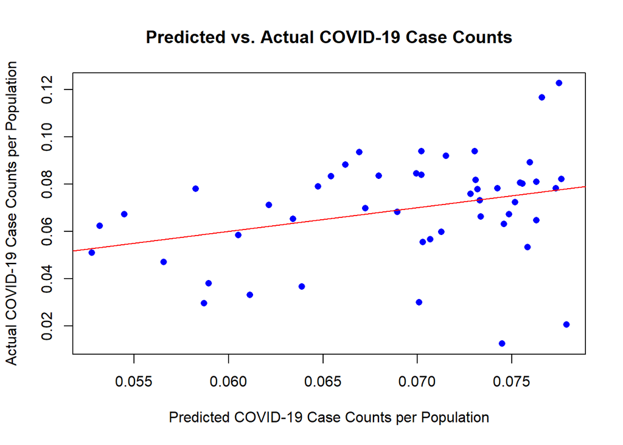

```r
# Predict COVID-19 case counts using the linear regression model
predictions <- predict(lm_model1)

# Create a scatter plot of actual vs. predicted COVID-19 case counts
plot(y= master_copy_2020$covid_case_count_per_pop, x= predictions,
     main = "Predicted vs. Actual COVID-19 Case Counts",
     ylab = "Actual COVID-19 Case Counts per Population",
     xlab = "Predicted COVID-19 Case Counts per Population",
     col = "blue",
     pch = 16)

# Add a diagonal line to represent perfect predictions
abline(0, 1, col = "red")
```

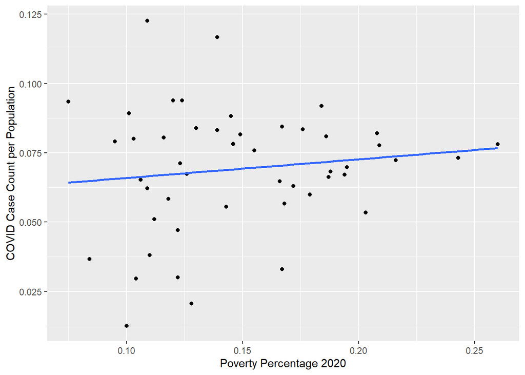

```r
# Create scatter plots with fitted regression lines for each predictor
ggplot(master_copy_2020, aes(x = Poverty_Percentage_2020, y = covid_case_count_per_pop)) +
  geom_point() +
  geom_smooth(method = "lm", se = FALSE) +
  labs(x = "Poverty Percentage 2020", y = "COVID Case Count per Population")
```

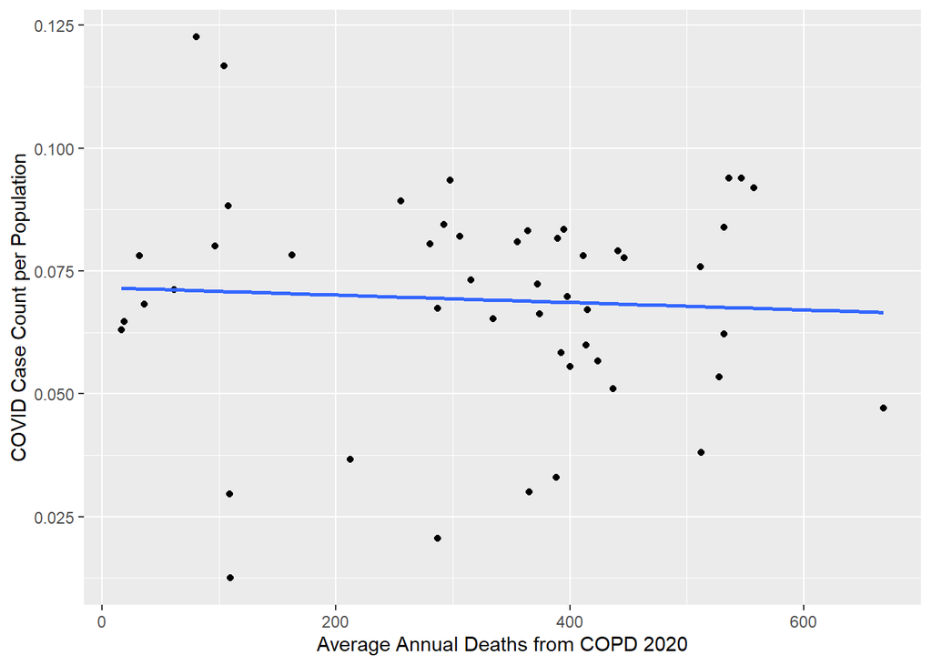

```r
 ggplot(master_copy_2020, aes(x = avg_annual_death_from_COPD_2020, y = covid_case_count_per_pop)) +
  geom_point() +
  geom_smooth(method = "lm", se = FALSE) +
  labs(x = "Average Annual Deaths from COPD 2020", y = "COVID Case Count per Population")
```

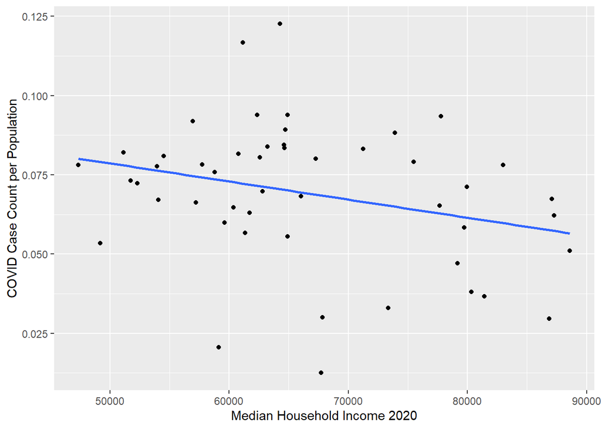

```r
ggplot(master_copy_2020, aes(x = Median_Household_Income_2020, y = covid_case_count_per_pop)) +
  geom_point() +
  geom_smooth(method = "lm", se = FALSE) +
  labs(x = "Median Household Income 2020", y = "COVID Case Count per Population")
```

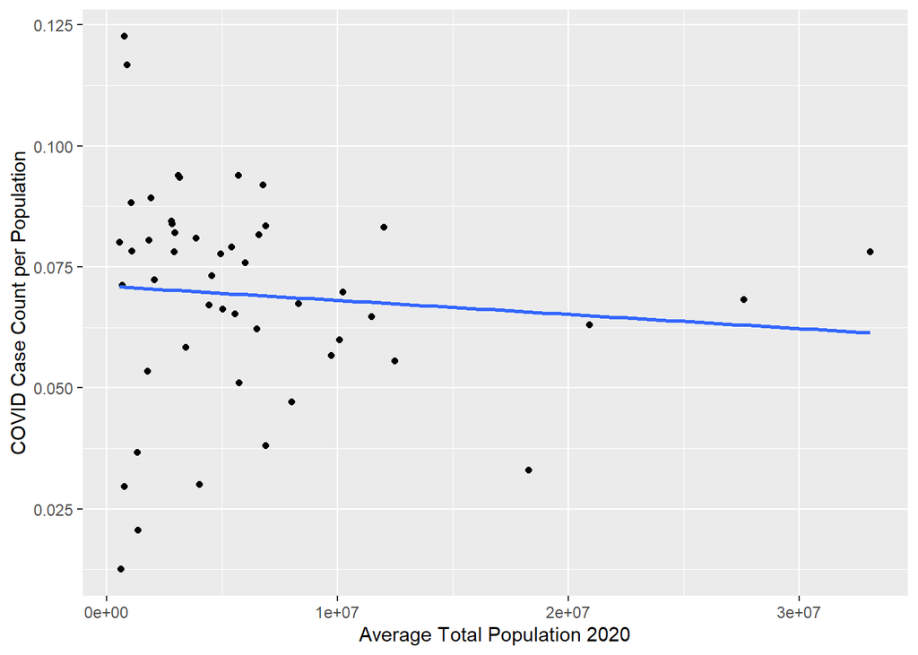

```r
 ggplot(master_copy_2020, aes(x = avg_total_population_2020, y = covid_case_count_per_pop)) +
  geom_point() +
  geom_smooth(method = "lm", se = FALSE) +
  labs(x = "Average Total Population 2020", y = "COVID Case Count per Population")
```

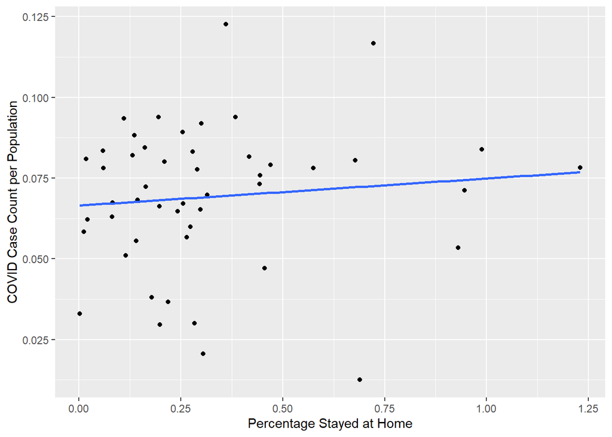

```r
 ggplot(master_copy_2020, aes(x = Percentage_stayed_at_home, y = covid_case_count_per_pop)) +
  geom_point() +
  geom_smooth(method = "lm", se = FALSE) +
  labs(x = "Percentage Stayed at Home", y = "COVID Case Count per Population")
```

##### Model 2

- **Analyze the model’s performance and summarize your findings.**

  **`Here is a summary of the model`**:
  1. **Coefficients**:
     - Each coefficient represents the change in the response variable (COVID-19 case count per population) for a one-unit change in the corresponding predictor variable, holding other variables constant.
     - The intercept (Intercept) is 1.041e+00, but it is not statistically significant (p = 0.774), suggesting that when all predictor variables are zero, the expected COVID-19 case count per population is not significantly different from zero.
     - Among the predictor variables:
       - Percentage_population_0_4, Percentage_population_5_19, Percentage_population_20_34, Percentage_population_35_54, Percentage_population_55_64, and Percentage_population_65_and_older represent different age groups’ percentages in the population. None of these variables are statistically significant predictors of COVID-19 case count per population, as indicated by their p-values (all above 0.05).
       - White_including_Hispanic_percent, Black_including_Hispanic_Percent, and Other_including_Hispanic_Percent represent the percentages of different racial groups in the population. None of these variables are statistically significant predictors of COVID-19 case count per population, as indicated by their p-values (all above 0.05).
       - American_Indian_including_Hispanic_Percent has an NA value for coefficient and standard error, indicating singularity or perfect multicollinearity with other variables.
  2. **Residuals**:
     - The residuals represent the differences between the observed and predicted values of the response variable.
     - The minimum residual is -0.033449, and the maximum residual is 0.034354.
  3. **Model Fit**:
     - The residual standard error is 0.01617, indicating the average deviation of the observed values from the fitted values.
     - The multiple R-squared value is 0.5756, suggesting that approximately 57.56% of the variability in the response variable is explained by the predictor variables in the model.
     - The adjusted R-squared value is 0.4777, which adjusts the R-squared value for the number of predictors in the model.
     - The F-statistic tests the overall significance of the model. With a p-value of 3.725e-05 (very low), we reject the null hypothesis that all coefficients are zero, indicating that at least one of the predictor variables has a non-zero effect on the response variable.

  Overall, this model suggests that the percentages of different age groups and racial groups in the population are not significant predictors of COVID-19 case count per population. Additionally, the presence of singularity or perfect multicollinearity with the variable American_Indian_including_Hispanic_Percent may require further investigation or model adjustment.

```r
# Linear Regression with demographics and race
lm_model2 <- train(covid_case_count_per_pop ~ Percentage_population_0_4 +
                   Percentage_population_5_19 +
                   Percentage_population_20_34 +
                   Percentage_population_35_54 +
                   Percentage_population_55_64 +
                   Percentage_population_65_and_older +
                   White_including_Hispanic_percent +
                   Black_including_Hispanic_Percent +
                   Other_including_Hispanic_Percent +
                   American_Indian_including_Hispanic_Percent,
                   data = master_copy_2020,
                   method = "lm")
```

[output not shown]

[output cut: 19 more lines]

[output not shown]

```r
summary(lm_model2)
```

```
##
## Call:
## lm(formula = .outcome ~ ., data = dat)
##
## Residuals:
##       Min        1Q    Median        3Q       Max
## -0.033449 -0.007971 -0.000102  0.009560  0.034354
##
## Coefficients: (1 not defined because of singularities)
##                                              Estimate Std. Error t value
## (Intercept)                                 1.041e+00  3.602e+00   0.289
## Percentage_population_0_4                   1.101e-02  3.892e-02   0.283
## Percentage_population_5_19                 -8.830e-03  3.551e-02  -0.249
## Percentage_population_20_34                -8.416e-03  3.663e-02  -0.230
## Percentage_population_35_54                -1.648e-02  3.605e-02  -0.457
## Percentage_population_55_64                -1.017e-02  3.566e-02  -0.285
## Percentage_population_65_and_older         -9.144e-03  3.611e-02  -0.253
## White_including_Hispanic_percent            4.391e-05  8.725e-04   0.050
## Black_including_Hispanic_Percent            4.222e-05  8.488e-04   0.050
## Other_including_Hispanic_Percent           -9.335e-04  9.842e-04  -0.948
## American_Indian_including_Hispanic_Percent         NA         NA      NA
##                                            Pr(>|t|)
## (Intercept)                                   0.774
## Percentage_population_0_4                     0.779
## Percentage_population_5_19                    0.805
## Percentage_population_20_34                   0.819
## Percentage_population_35_54                   0.650
## Percentage_population_55_64                   0.777
## Percentage_population_65_and_older            0.801
## White_including_Hispanic_percent              0.960
## Black_including_Hispanic_Percent              0.961
## Other_including_Hispanic_Percent              0.349
## American_Indian_including_Hispanic_Percent       NA
##
## Residual standard error: 0.01617 on 39 degrees of freedom
## Multiple R-squared:  0.5756, Adjusted R-squared:  0.4777
## F-statistic: 5.878 on 9 and 39 DF,  p-value: 3.725e-05
```

```r
# Predict COVID-19 case counts using the linear regression model
predictions <- predict(lm_model2)
```

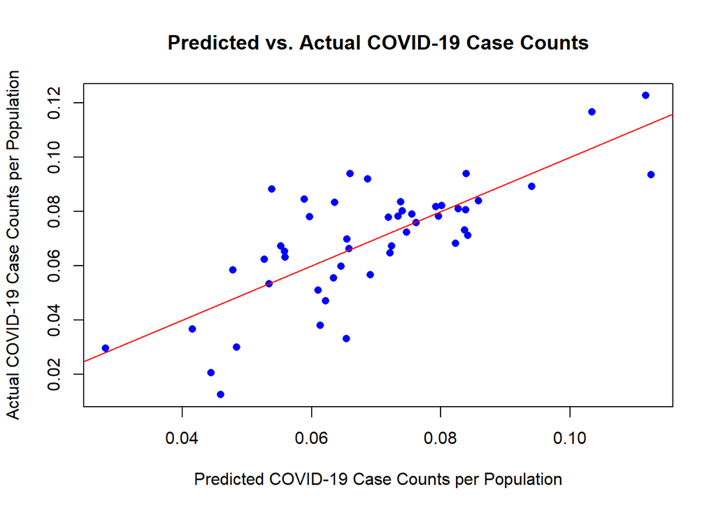

```r
# Create a scatter plot of actual vs. predicted COVID-19 case counts
plot(y= master_copy_2020$covid_case_count_per_pop, x= predictions,
     main = "Predicted vs. Actual COVID-19 Case Counts",
     ylab = "Actual COVID-19 Case Counts per Population",
     xlab = "Predicted COVID-19 Case Counts per Population",
     col = "blue",
     pch = 16)

# Add a diagonal line to represent perfect predictions
abline(0, 1, col = "red")
```